# Posłowie

Dominik Krystkowiak Łukasz Śmierzchalski

15 12 2019

# Posłowie

## Pobieranie danych z Internetu - modyfikacja skryptu

W skrypcie dokonano następujących zmian:

- dodano wyciąganie danych związanych z okręgiem wyborczym

```r
pola <- c("Liczba głosów:", "Klub/koło:", "Data i miejsce urodzenia:", "Wykształcenie:", "Zawód:", "Nazwisko:", "Okręg wyborczy:")

colnames(df) <- c("Liczba.Glosow", "Klub", "Data", "Wyksztalcenie", "Zawod", "ImieNazwisko", "OkregWyborczy")
```

- poprawiono wyciąganie wieku na podstawie datu urodzenia; w tym celu użyto funkcji **age_calc**, następnie uzyskany rezultat zaokrąglono w dół za pomocą funkcji **floor**

```r
poslowie$Wiek <- floor(age_calc(poslowie$DataUrodzenia, units = "years"))
```

- dodano wyciąganie danych na temat płci na podstawie imienia; w tym celu stworzono funcję **get_gender**, która dzieli ciąg znaków według spacji ( **strsplit**), następnie z 1 elementu tablicy brany jest ostatni znak ( **stri_sub**), jeżeli jest to literka “a” jest to kobieta w przeciwnym razie mężczyzna

```r
get_gender <- function(name) {
  if (all(stri_sub(unlist(strsplit(toString(name), " "))[1], -1, -1) == "a")) {
    return("K")
  } else {
    return("M")
  }
}

poslowie$Plec <- sapply(poslowie$ImieNazwisko,get_gender)
```

- uzyskany wynik zostaje zapisany do pliku CSV w celu zapobiegnięcia ciągłemu pobierania danych ze strony (ciągłe odpytywanie prowadzi do tymczasowego zablokowanie adresu - kod błędu 403 Forbidden)

```r
write.csv(poslowie,'deputies.csv', row.names = TRUE)
```

Efekt końcowy

```r
poslowie <- list()
for (posel in 1:460) {
  strona <- read_html(paste0("http://sejm.gov.pl/sejm8.nsf/posel.xsp?id=",posel%/%100, (posel%/%10)%%10, posel %% 10))
  nazwisko <- html_text(html_nodes(strona, "h1"))

  pola <- html_text(html_nodes(strona, ".data p"))
  if (any(pola == "Wygaśnięcie mandatu:")) {
    ind <- which(pola == "Wygaśnięcie mandatu:")
    pola <- pola[-ind+c(0,-1)]
    if (!grepl(pola[ind], pattern=":$"))
      pola <- pola[-ind]
  }
  wartosci <- pola[seq(2, length(pola), 2)]
  names(wartosci) <- pola[seq(1, length(pola), 2)]
  wartosci[["Nazwisko:"]] <- nazwisko
  id <- as.character(posel)
  poslowie[[id]] <- wartosci
}

pola <- c("Liczba głosów:", "Klub/koło:", "Data i miejsce urodzenia:", "Wykształcenie:", "Zawód:", "Nazwisko:", "Okręg wyborczy:")

dane <- list()
for(pole in pola) {
  dane[[pole]] <- sapply(poslowie, function(posel) posel[pole])
}

df <- as.data.frame(dane)
colnames(df) <- c("Liczba.Glosow", "Klub", "Data", "Wyksztalcenie", "Zawod", "ImieNazwisko", "OkregWyborczy")
rownames(df) <- names(poslowie)
df$Klub <- gsub(df$Klub, pattern = "Klub Parlamentarny |Klub Poselski ", replacement="")
df$DataUrodzenia <- gsub(df$Data, pattern = ",.*$", replacement = "")
df$MiejsceUrodzenia <- gsub(df$Data, pattern = "^.*,.", replacement = "")

get_gender <- function(name) {
  if (all(stri_sub(unlist(strsplit(toString(name), " "))[1], -1, -1) == "a")) {
    return("K")
  } else {
    return("M")
  }
}

poslowie <- df[,-3]
poslowie$Liczba.Glosow <- as.numeric(as.character(poslowie$Liczba.Glosow))
poslowie$Klub <- factor(poslowie$Klub)
poslowie$DataUrodzenia <- dmy(poslowie$DataUrodzenia)
poslowie$MiejsceUrodzenia <- factor(poslowie$MiejsceUrodzenia)
poslowie$Wiek <- floor(age_calc(poslowie$DataUrodzenia, units = "years"))
poslowie$Plec <- sapply(poslowie$ImieNazwisko,get_gender)
write.csv(poslowie,'deputies.csv', row.names = TRUE)
```

## Opis funkcji

- **list**() - utworzenie listy
- **read_html**(file) - odczytanie zawartości pliku .html
  - file - ścieżka do pliku .html
- **paste0**() - konkatenacja serii ciągów znaków bez żadnego separatora
- **html_nodes**(document, node) - wyciągncięcie z dokumentu podanego węzła
  - document - zawartość .html
  - node - jaki węzeł jest poszukiwany
- **html_text**() - wyciągniecie wartości danego tagu, w przypadku skryptu powyżej szukamy klasy data oraz wyciągamy wszystkie wartości znajdujące się w znaczniku
- **any**() - sprawdzane jest czy jakiś warunek podany w funkcji równa się TRUE
- **which**() - zwracana są indeksy wektora, które spełniają warunek
- **length**() - zwracana jest długość zmiennej
- **grepl**() - zwraca prawdę jeżeli ciąg znaków zawiera podany wzorzec
- **sapply**(x, fun) - zastosowanie podanej funkcji (fun) dla listy, wektora lub ramki danych (x)
- **c**() - łączy podane argumenty w wektor
- **gsub**() - zamiana znaków spełniających wzorzec
- **toString**() - konwersja danej na typ string
- **strsplit**() - podział łańcucha znaków według separatora
- **unlist**() - zamiana listy na wektor
- **stri_sub**() - pozwala na wydzielenie podciągu z ciągu znaków
- **all**() - zwraca TRUE, jeżeli wszystkie warunki logiczne są prawdziwe
- **as.numeric**() - konwersja na typ numeryczny
- **as.character**() - konwersja na typ znakowy
- **as.data.frame**() - konwersja na ramkę danych
- **factor**() - zmiana wektora na czynniki
- **dmy**() - parsowanie daty na dzień, miesiąc, rok
- **floor**() - zaokrąglenie w dół
- **age_calc**() - wylicza czas pomiędzy dwiema datami
- **write.csv**() - zapis ramki danych do pliku csv

##Wykresy

```r
# ANALYSIS
poslowie_data <- read.table(file = "deputies.csv", sep=",", header=TRUE)
head(poslowie_data)
```

```
##   X Liczba.Glosow                                         Klub  Wyksztalcenie
## 1 1         10500                       Prawo i Sprawiedliwość         wyższe
## 2 2         18514                       Prawo i Sprawiedliwość         wyższe
## 3 3          7275 Platforma Obywatelska - Koalicja Obywatelska         wyższe
## 4 4         15668                           Poseł niezrzeszony         wyższe
## 5 5         12021                       Prawo i Sprawiedliwość         wyższe
## 6 6          7935                                     Kukiz'15 średnie ogólne
##                        Zawod        ImieNazwisko OkregWyborczy DataUrodzenia
## 1              poseł na Sejm     Adam Abramowicz      7  Chełm    1961-03-10
## 2           parlamentarzysta    Andrzej Adamczyk    13  Kraków    1959-01-04
## 3         agroprzedsiębiorca    Zbigniew Ajchler      38  Piła    1955-11-21
## 4 specjalista ds. medialnych Adam Andruszkiewicz 24  Białystok    1990-06-30
## 5           poseł na Sejm RP     Waldemar Andzel 32  Sosnowiec    1971-09-17
## 6                dziennikarz          Piotr Apel       9  Łódź    1984-02-08
##   MiejsceUrodzenia Wiek Plec
## 1   Biała Podlaska   58    M
## 2      Krzeszowice   60    M
## 3        Szamotuły   64    M
## 4          Grajewo   29    M
## 5          Czeladź   48    M
## 6         Warszawa   35    M
```

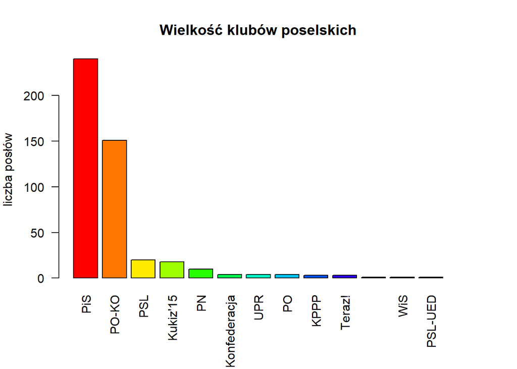

```r
#summary(poslowie_data)

#mean(as.numeric(poslowie_data$Liczba.głosów))
#table(poslowie_data$Wyksztalcenie)
#factor(poslowie_data$MiejsceUrodzenia)
#poslowie_data$Klub

#CHARTS

#klub poselski - liczba członków -> kolumnowy
table_1 = table(poslowie_data$Klub)
df_1 = as.data.frame(table_1)
names(df_1)[1] = 'klub'
names(df_1)[2] = 'liczba_poslow'
df_1 <-df_1[order(-df_1$liczba_poslow),]
par(mar=c(6,4,4,4))
barplot(df_1$liczba_poslow,names.arg=c("PiS","PO-KO","PSL", "Kukiz'15", "PN", "Konfederacja", "UPR", "PO", "KPPP", "Teraz!","","WiS","PSL-UED"),ylab="liczba posłów",col=rainbow(length(df_1$klub)),
        main="Wielkość klubów poselskich",border="black",las=2)
```

Partia rządząca oraz największa partia opozycyjna posiadają wielu członków, pozostałe kluby są małe.

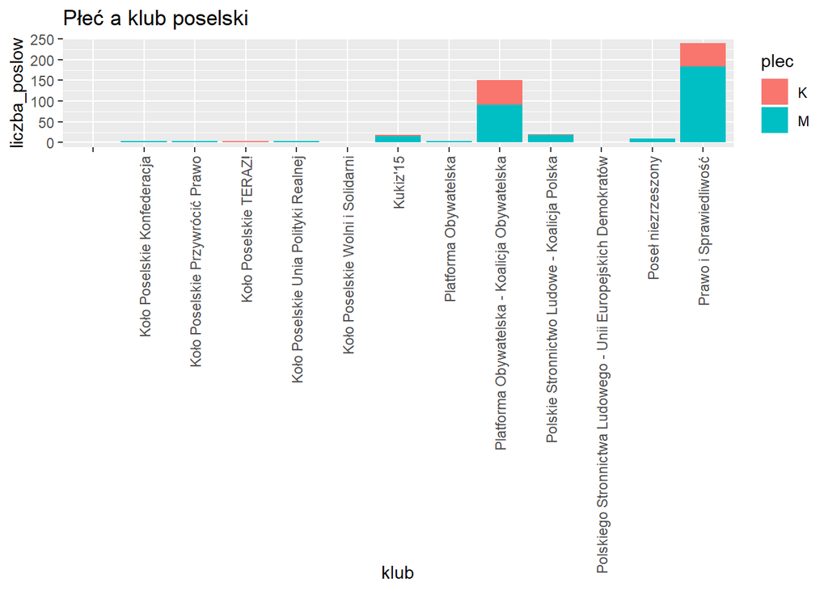

```r
#klub poselski - plec
df_5 <- data.frame(
  plec=poslowie_data$Plec ,
  klub=poslowie_data$Klub
)
df_5 <- ddply(df_5, .(df_5$plec, df_5$klub), nrow)
names(df_5) <- c("plec", "klub", "liczba_poslow")

df_5 <-df_5[order(-df_5$plec),]
df_5 <-df_5[order(-df_5$klub),]

par(mar=c(13,4,4,4))
ggplot(data=df_5, aes(x=klub, y=liczba_poslow, fill=plec)) +
  geom_bar(stat="identity")+
  theme(axis.text.x=element_text(angle=90,hjust=1,vjust=0.5))+
  ggtitle("Płeć a klub poselski")
```

Kobiety stanowią mniejszość wśród praktycznie wszystkich klubów poselskich.

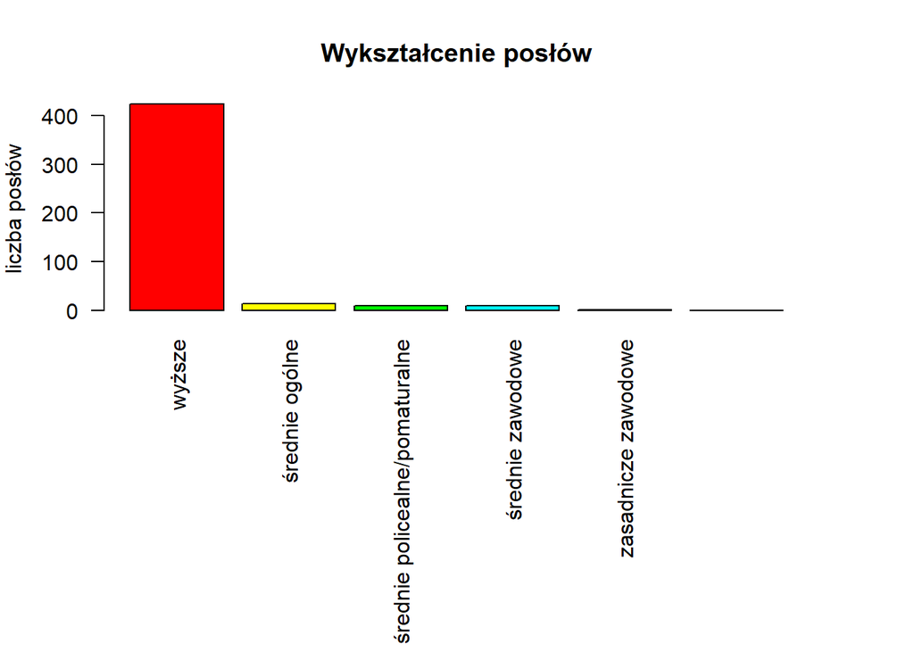

```r
#wyksztalcenie
table_2 = table(poslowie_data$Wyksztalcenie)
df_2 = as.data.frame(table_2)
names(df_2)[1] = 'wyksztlcenie'
names(df_2)[2] = 'liczba_poslow'
df_2 <-df_2[order(-df_2$liczba_poslow),]
par(mar=c(13,4,4,4))
barplot(df_2$liczba_poslow,names.arg=df_2$wyksztlcenie,ylab="liczba posłów",col=rainbow(length(df_2$wyksztlcenie)),
        main="Wykształcenie posłów",border="black",las=2)
```

Wykształcenie wyższe posiada znaczna większość posłów. Ciekawostka - Z 400 najbogatszych Amerykanów tylko około 130 posiada formalne wykształcenie z czego aż 63 osoby tylko średnie.

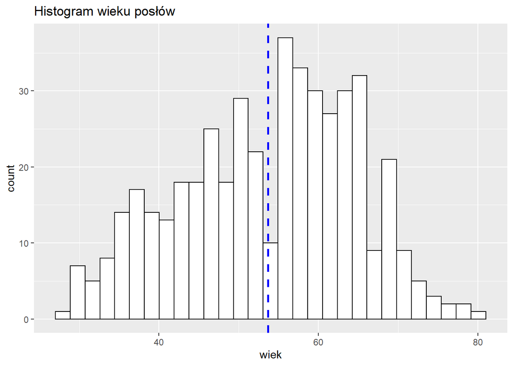

```r
#histogram wiek
df_3 = as.data.frame(poslowie_data$Wiek)
names(df_3)[1] = 'wiek'

ggplot(df_3, aes(x=wiek)) +
  geom_histogram(color="black", fill="white") +
  geom_vline(aes(xintercept=mean(wiek)),
             color="blue", linetype="dashed", size=1)+
  ggtitle("Histogram wieku posłów")
```

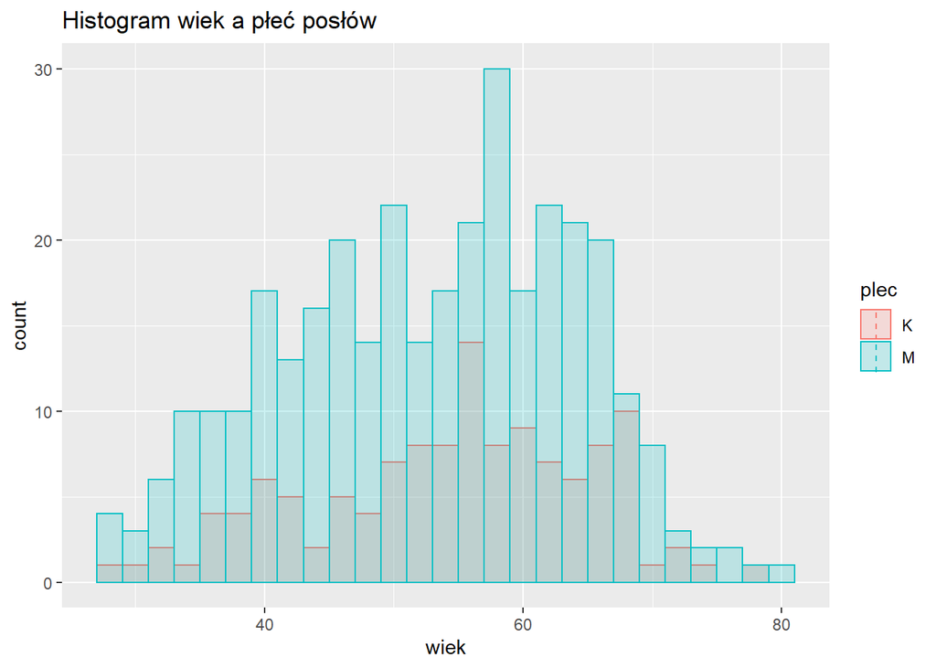

```r
#histogram wiek płeć
df_4 <- data.frame(
  plec=poslowie_data$Plec ,
  wiek=poslowie_data$Wiek
)

mu <- ddply(df_4, "plec", summarise, grp.mean=mean(plec))

ggplot(df_4, aes(x=wiek, fill=plec, color=plec)) +
  geom_histogram( alpha=0.2, position="identity", binwidth=2) +
  geom_vline(data=mu, aes(xintercept=grp.mean, color=plec),
              linetype="dashed")+
  ggtitle("Histogram wiek a płeć posłów")
```